# Who’s afraid of Virginia Woolf? Providing empirical foundations for future investigations of *free indirect style* and perspective shifts

Giulia Grisot, Kathy Conklin, Violeta Sotirova - The University of Nottingham

10 July 2019

# Abstract

Virginia Woolf’s works are considered to be challenging, in particular because of the techniques of speech and thought presentation she adopts – *free indirect style* and interior monologue – and of her experimental way of handling them, which often results in ambiguous perspective shifts. Woolf’s work has been the object of several studies concerned with the complexity of these techniques, which investigated the way in which different perspectives coexist and alternate in her writing. However, there is hardly any empirical evidence as to whether readers experience difficulty while reading her narratives as a result of this complexity, or if they do so because of the way perspectives are presented. The present paper examines empirically readers’ responses to extracts from Woolf’s two major novels – *To the Lighthouse* and *Mrs Dalloway* – to provide evidence to whether Woolf’s techniques for the presentation of characters’ perspectives represent a challenge for readers. To achieve this, a mixed methods approach that combines a stylistic analysis with a detailed questionnaire has been employed. Selected passages that were hypothesized to be complex due to the presence of *free indirect style* and/or interior monologue were modified by substituting these with less ambiguous modes of consciousness presentation, such as direct speech or direct thought. Readers’ responses to the modified and unmodified versions of the same passages were compared: results show that the presence of *free indirect style* and/or interior monologue increases the number of perspectives identified by readers, suggesting that this technique increases the texts’ difficulty, and laying a more solid ground for future investigations.

Keywords: empirical study of literature; Virginia Woolf; reader response; stylistics, *free indirect style*

# Introduction

Modernist literature is typically qualified by critics as being obscure and complex in comparison with realist poetry and prose (Diepeveen, 2003; Levenson, 2013; Mahaffey, 2008; Quigley, 2015). The social and cultural changes that took place between the end of the nineteenth and the first decades of the twentieth century triggered the desire for a new and more direct way of representing reality in the arts and pushed artists to break earlier conventions and to find new strategies for portraying their impressions of the world, which often resulted in alienating works. Modernist literature features a departure from the traditional structure of narratives: it demolishes the role of the narrator and the spatial and temporal constraints of the traditional plot, in an attempt to convey the complex dynamics of real life experiences. This is realised in particular through the use of experimental narrative techniques for the presentation of speech, thoughts, perceptions and states, which, as we will discuss in more detail below, are particularly prevalent in Woolf’s works.

As one of the most prominent writers of the Modernist movement, Virginia Woolf’s novels and critical essays are often quoted in discussions concerning consciousness presentation. Her writing is considered difficult by many literary critics, and her novels are generally believed to represent a challenge for readers (Diepeveen, 2003; Goldman, 2006; Mahaffey, 2008; Quigley, 2015). This is supported by a number of informal surveys, where her novels feature prominently[^1]. In line with literary criticism (Castiglione, 2019), these surveys highlight aspects of her writing that seem to represent a major challenge for readers, in particular the perceived lack of a plot, the sometimes incomplete or intricate syntax, and the difficulty in understanding whose perspective or voice is presented within a specific passage. What the present paper argues is that these challenging aspects of her writing can be regarded as the result of her experimental use of several techniques of speech, thought and consciousness presentation.

Such techniques have been described by different models of speech and thought presentation, such as the ones developed by Banfield (1982) and Leech and Short (2007). These models draw a precise map of the various speech and thought presentation techniques, classifying each category according to specific syntactic boundaries. As Palmer (2004) and Sotirova (2013) suggest, however, these models often appear to simplify the presentation of fictional consciousness, forcing it into categories that exclude expressions of characters’ inners states that are not readily translatable into articulated thoughts. Taking in consideration both approaches, Rundquist (2014) propose a model that combines a closer linguistic description of the categories of consciousness presentation with a focus on their semantic effects and on the different facets of the fictional minds they portray.

Free Indirect Speech (FIS) (Leech and Short, 2007) presents characters’ utterances without the typical marks of direct speech, featuring the expressive constructs and discourse patterns of a character’s spoken language. Similarly, Free Indirect Thought (FIT) (Leech and Short, 2007) expresses characters’ thoughts featuring the character’s language patterns, without reporting the articulated thoughts directly. In contrast, Interior Monologue (IM) – also called Free Direct Thought – can be distinguished from other forms of *free indirect style* as it renders a character’s thoughts in their direct form. As with FIT, it omits speech marks, but in contrast to FIT, its narration is consistently conversed in the first person. The same difference exists between FIS and Free Direct Speech (FDS), the latter describing substantially an instance of non-signalled Direct Speech. FIS, FIT and IM render a character’s verbalised speech or thoughts, eliminating the narrator’s filter. The two following categories, on the other hand, convey the characters’ perceptions or states without expressing verbalized thoughts. They are formally closer to the narratorial ‘voice’, even though they do not necessarily imply the viewpoint of a narrator, which only exists as a ‘means’ to report those perceptions and feelings. These are Represented Perception (RP henceforward) (Brinton, 1980), which describes the narrative world as filtered through a character’s point of view, and Consonant Psycho-narration (PN henceforward) (Cohn, 1978), which conveys a character’s state of mind, feelings, or other mental operations in the voice of the narrator, but without implying an external vantage point.

The following extract from *To the Lighthouse* offers an example of some of the complexity of Woolf’s use of these techniques to portray fictional consciousnesses and points of view, and a first glimpse of what makes them challenging for readers to understand. The passage, described by Leaska (1970: 107) as ‘a sequence of startling and often ironic juxtapositions, but also designed a mental hall of mirrors furnished with human emotions, reflections, memories’, is taken from one of the most well-known scenes of the novel, where the Ramsays and their guests are sitting at the dinner table and have just started their meal. The conversation and their attention is initially directed to the main dish, which works as a convergence point for Mrs. Ramsay’s and Mr. Bankes’ perspectives.

> [1] ‘It is a triumph,’ [2] said Mr. Bankes, laying his knife down for a moment. [3] He had eaten attentively. [4] It was rich; it was tender. It was perfectly cooked. [5] How did she manage these things in the depths of the country? [6] he asked her. [7] She was a wonderful woman. [8] All his love, all his reverence had returned; [9] and she knew it.

> (Woolf, 1994: 72)

The direct speech in [1] and the reporting clause followed by the temporal adverbial non-finite clause in [2] introduces the reader’s attention to Mr Bankes. However, it is not immediately clear whose perspective is presented in [3]. At first, He had eaten attentively could be classified as purely narratorial: it does not present the typical markers of *free indirect style*, nor any fragmentation or syntactic ambiguity. After reading [4], however, this intuition leaves space for a second interpretation, in favour of a more character-oriented viewpoint. [3] works in fact as a ‘bridge’, helping the reader to shift into Mr. Bankes’ perspective. The three very short sentences and the parallelism of it was in [4] evoke in fact the ‘orality’ typical of *free indirect style* (Adamson, 1994), conveying what seems to be Mr. Bankes’ self-conscious satisfaction and sense of approval for the food – the not-yet disclosed main course referred to as ‘it’. Because it does not seem likely that Mr Bankes would refer to the food he is still eating in the past tense (he’s just laying his knife down for a moment], it appears most likely that this sentence presents his FIT or FIS, in what could be translated into a direct form as ‘It is rich; it is tender; it is perfectly cooked’.

Thanks to the reporting clause in [6] it is possible to classify [5] as a clear example of FIS – as signalled by the third person pronoun alongside the past tense typical of this technique – where Mr Bankes’ voice is presented. [7] is again more ambiguous: on the one hand, it could still be expressing Mr. Bankes’ voice, in an overt compliment to Mrs. Ramsay. On the other hand, it could be either an articulated thought, and therefore FIT, or a presentation of Mr Bankes’ non articulated feelings, which could be then classified as PN. [8] is probably even more ambiguous, and so is [9]: the first is an example of PN, which, at first, can be interpreted as portraying Mr. Bankes’ feelings in the voice of the narrator but from an internal vantage point. However, as soon as [9] is read, the rendering of the whole sentence can assume a different ‘flavour’. The clause and she knew it, at the end of the extract, conveys in fact Mrs. Ramsay’s internal state, which relates to – and appears to result from – the previous sentence. Is [8] portraying Mr. Bankes’ or Mrs. Ramsay’s feelings? Although [9] seems to push towards the second interpretation, both are possible. What is particularly interesting in these last two clauses is that the shift between modes, and – probably – between two characters’ perspectives, happens within the same sentence and is moreover accompanied by a conjunction which creates a sense of dialogue (Sotirova, 2013) (the prominence of such shifts in *To the Lighthouse* was highlighted already in Leaska (1970)).

Woolf’s use of these techniques is experimental in several ways. She plays with perspectives and points of view, almost fusing together characters’ perspectives and voices by juxtaposing different characters’ viewpoints and by switching abruptly between various techniques of consciousness presentation, thus creating a dynamic experience where the reader has access to multiple facets of the characters’ minds. Her writing is comparable to a ‘camera-like’ motion, where the observation point suddenly and quickly shifts from one position to another, inside and outside characters, offering insights into the various minds while allowing at the same time an outer perspective of the represented fictional world. This effect is realised through an extreme fragmentation of the narrative, both in terms of storyline and in terms of syntax. The syntactic deviance can be considered an effect of the shifts between perspectives and between modes of consciousness presentation, and a result of Woolf’s use of *free indirect style*, IM or FDS, and this is particularly relevant to the identification of difficulty within Woolf’s novels *To the Lighthouse* and *Mrs Dalloway*.

Woolf’s texts have been used in several studies to explore questions about readers’ reactions to literature (Brooke et al., 2016; Miall, 1989; Van Peer, 2007; Van Peer et al., 2007; Wilson, 1981; Zunshine et al., 2003; Zyngier et al., 2007). Only a few studies, however, investigate empirically reader’s attributions of perspectives within her novels (Bray, 2007b; Cui, 2017; Sotirova, 2007, 2016). Even if these do not focus specifically on difficulty, their results suggest that shifts between perspectives and modes are indeed challenging for readers. The current research builds on these results to investigate readers’ response to Woolf’s experimental use of *free indirect style*, IM and FDS, focusing on the shifts between characters’ perspectives and, crucially, between different modes of consciousness presentation, to understand whether actual readers struggle with interpreting whose voice, thoughts or consciousness are presented in her narratives.

# Difficulty and Woolf’s use of *free indirect style*

Within literary studies, the term *difficulty*, or *complexity* has been used in different ways, generally pointing to texts that are believed to be challenging to understand due to non-standard uses of lexical items, or deviant syntactic structures. *Free indirect style* can be considered difficult both grammatically, semantically and pragmatically. It combines the directness of verbalised speech and thoughts with the third person reporting style typical of indirect speech, using the flavour of characters’ expressivity to portray the fictional world from their viewpoint, whilst annihilating the narratorial ‘voice’, juxtaposing therefore two (or more) perspectives. *Free indirect style* can convey speech and thoughts that could be plausibly articulated and verbalised by characters, as well as characters’ impressions of the fictional world that surrounds them, therefore allowing speech, thoughts and other aspects of consciousness to be presented to the reader. An effect of this technique, which will be analysed further below, is that ‘it is often difficult to identify precisely the source of the speaking voice’ (Bosseaux, 2007: 54).

> [1] She was still attractive, still a personage, Sally Seton. But who was this Rosseter? [2] He wore two camellias on his wedding day – [3] that was all Peter knew of him. [4] ‘They have myriads of servants, miles of conservatories,’ Clarissa wrote; something like that. [5] Sally owned it with a shout of laughter.

> [6] ‘Yes, I have ten thousand a year’ – [7] whether before the tax was paid or after, she couldn’t remember, for her husband, [8] ‘whom you must meet,’ she said, ‘whom you would like,’ she said, [9] did all that for her.

> (Woolf, 1996: 136)

The passage opens with Peter’s FIT in [1], which is marked by the past tense, the evaluation, the use of deixis and the parallelism still attractive, still a personage and the rhetorical question, including deixis, in who was this Rosseter?. This leads to a presentation of his thoughts in [2] in what can be identified as IM or FIT, where the past tense is no longer functioning as part of the combination of different deictic systems typical of *free indirect style*, but instead refers directly to the character’s past. The dash breaks the sentence syntactically, and this anacoluthon allows for a shift that brings the reader back to Peter’s FIT in [3].

As a result of Woolf’s use of free indirect forms of speech and thought representation, the novels feature a general lack of punctuation to signal speech and thought. Sometimes, however, Woolf adopts the same marks a reader would expect to find in direct speech to present a someone else’s words embedded in a character’s FIT. Such reports are often embedded within FIT, and can cause an interpretative ambiguity for readers, at least on first reading. This happens for example in [4], where Clarissa’s voice appears to interrupt Peter’s flow of thoughts.

The examples above briefly show how Virginia Woolf’s use of several techniques for the presentation of speech, thoughts and consciousness and the quick shifts between them can be challenging to interpret in terms of perspective attribution. Her extensive use of such techniques in *To the Lighthouse* and *Mrs Dalloway* makes the two novels problematic for readers on different levels: on the one hand, because of the constant focus on characters and their feelings, the plot does not follow a progression of events typical of traditional narratives. Woolf de-constructs the time of the narrative (Matz, 2008), emphasising the representation of experiences as opposed to that of actions. This is further enhanced by the suppression and the minimal presence of the narrator.

On the other hand, as shown in the examples above, Woolf thins the boundaries between perspectives, as well as between different modes of consciousness presentation (Cui, 2017; Rundquist, 2015; Sotirova, 2016). The juxtaposition of the various modes without signalling the change from one to the other, the absence of clear boundaries between narration, speech, thoughts and perceptions of the characters, and the grammatical inconsistency resulting from missing references, ellipsis, and colloquialisms, present potential difficulties for readers, which do not allow for a clear and unequivocal interpretation of the represented fictional world.

## Approaches to the identification of perspective

The juxtaposition of the various techniques of *free indirect style* and the more direct more of IM in Woolf make it challenging to distinguish between thoughts and speech, as well as to determine their source – a particular character or the narrator. Thus, an important potential source of difficulty arising from Woolf’s use of *free indirect style* and IM relates to the identification of perspectives.

A number of scholars have looked at the attribution of perspective within texts featuring *free indirect style*. (Semino et al., 1997), for example, used a corpus of forty literary and non-literary British English 20th century texts to investigate the different forms of speech and thought presentation. They showed that a high number of ambiguities occur as a consequence of the use of the different techniques of speech and thought presentation. Bray (2007a) investigated how readers respond to *free indirect style*, in an attempt to resolve the theoretical dispute on whether *free indirect style* conveys only one or more than one consciousness at the same time (for more about the single voice vs. dual voice hypothesis see Banfield (1982); Fludernik (1996); Galbraith (2012); Pascal (1977); Sotirova (2011)). To address this question, he asked participants to identify voices within two literary passages and to indicate whose voice they thought was represented by selecting either one named character, the narrator only, both the narrator and the character or ‘impossible to decide’. In the second part of the study, participants were asked to recognise point of view instead of voice. In this task, the character was no longer specified as a possible answer. Results showed that attributions for sentences containing *free indirect style* varied between readers.

In a similar vein, Sotirova (2016) looked into readers’ responses to the passage quoted above, and examined how readers responded to frequent shifts in point of view, as well as a variety of different modes of speech and thought presentation. Participants were asked to identify perspectives in the passage and to signal the boundaries between viewpoints. The study also aimed to examine how much readers with different reading experience (undergraduate vs. postgraduate students of English) agreed in interpreting and assigning perspectives. Results showed that more experienced students more often opted for a dual voice interpretation, assigning perspective to a character and to the narrator at the same time. This suggests that they were generally more sensitive to *free indirect style*, and that therefore experience and knowledge could play a role in how readers interpret narratives featuring this technique. Despite the small and not balanced number of participants (15 UG vs. 8 PG, of which 3 non native speakers of English), what emerges from this study, crucially, is that even within a short extract such as the one used in this experiment, a large number of shifts were signalled by both groups, with many different possible interpretations.

Both Bray and Sotirova showed that individual responses varied; on the one hand, this means that no definitive answer was found for the single/dual voice debate. On the other hand, and interestingly for the present study, because responses were not homogeneous, this indicates that attributions are difficult in such texts. However, both of these studies imposed limitations that prevent us from drawing the widest possible conclusions about perspective attribution. Bray (2007a) presented readers with texts imposing the sentence or even the paragraph as a unit for attribution, and provided fixed choices. His results are therefore unlikely to show the full extent of issues surrounding attribution. As shown in the examples in section 2, shifts between modes of consciousness presentation frequently happen within sentences in Woolf’s narratives. Moreover, the boundaries between these modes are not signalled, and allow for multiple interpretations of whose perspective or what aspect of consciousness is being presented. Sotirova (2016) took a step forward, presenting the text unmarked, and avoided mentioning the sentence as a unit in the instructions given. However, Sotirova did not distinguish between different modes of consciousness presentation, asking readers to indicate only whose ‘viewpoint’ or ‘voice’ was expressed in the text, therefore not accounting for the differences in the interpretation of verbalised thoughts, non-verbalised thoughts and speech, which often contribute to the difficulty of Woolf’s novels.

More recently, Cui (2017) explored the attribution of perspective in three extracts from: Jane Austen’s novel Sense and Sensibility, Katherine Mansfield’s short story ‘Life of Ma Parker’, and Virginia Woolf’s *To the Lighthouse*. Participants were asked to read the texts on a computer screen twice, and their reading times were measured. Participants were then asked to identify whose point(s) of view the whole passage was narrated from, and to rate the passage in terms of perceived difficulty. Cui found a higher degree of agreement for passages with no shifts between perspectives compared to those featuring shifts. With regard to difficulty, the passage with shifts was rated as slightly more difficult than the others. Finally, reading times, Cui writes, were ‘roughly consistent’ with the results of the rating of difficulty. These results seem to support the present paper’s hypothesis that *free indirect style* poses a challenge for readers, particularly the variety practised by Woolf. However, several aspects of Cui’s study warrant further investigation: firstly, by using texts from different authors, a number of variables that are related to the writing style and that could be related to difficulty (e.g. grammatical complexity, use of metaphor) were not taken into account. Secondly, although the passages from Sense and Sensibility and ‘Life of Ma Parker’ did not feature shifts from one character’s perspective to another’s, they did feature *free indirect style*, and not consistently in a single mode. This means that shifts occurred between represented speech, thoughts and perceptions of the characters. Moreover, by presenting the passages as a whole on a screen, it is possible, or even likely, that participants only signalled the most prominent perspective they perceived, or the most prominent in combination with that of the narrator[^2]. Crucially, Cui’s results show that multiple perspectives were assigned by readers in all passages, all of which featured *free indirect style*. Finally, the assumption that shifts in perspective should cause slower reading times has to be considered in light of the stylistic differences between authors (more or less parataxis, word frequency), and, crucially, in light of the different uses of *free indirect style*. For instance, Mansfield and Austen do not use *free indirect style* to juxtapose various characters’ consciousnesses, but rather to evoke empathy and irony. Considering Woolf’s experimentalism with this technique and her attempt to reproduce orality (Adamson, 1998; Biber and Finegan, 1989), it is not unlikely that her texts are read faster, rather that slower, than both Mansfield and Austen.

Building on previous studies, the current research asks participants to signal whose thoughts, voice or perspective is being presented in eight extracts from *Mrs Dalloway* and *To the Lighthouse*. However, there are some key differences in our procedure: firstly, passages were presented without providing any indication where shifts may occur by imposing demarcated text units. Namely, as we have seen in the example in section 2, often shifts between modes and perspectives happen within a sentence. Secondly, no input or constraints on participants’ attributions were provided (e.g. offering overt choices of characters and narrator for the source of perspective). This was thought to be useful in demonstrating more definitively how many different points of view can be identified by readers. Thirdly, and crucially, because the different techniques of consciousness presentation can convey different facets of consciousness – i.e speech, thoughts, and perceptions/states – these were counted as distinct viewpoints even when they can be attributed to the same character.

# The Study

## Materials

In order to evaluate whether difficulty in the two novels by Virginia Woolf (*Mrs Dalloway* and *To the Lighthouse*) arises from the way in which perspectives are presented, specifically in relation to the use of *free indirect style*, eight passages were selected (five from *Mrs Dalloway* and three from *To the Lighthouse*) that contained instances of this technique, as well as of IM. If the presence of *free indirect style* and IM makes perspective identification challenging, removing it should allow readers to identify voice/perspective with greater ease.

For each passage, a modified version was created, where the hypothesised difficulties arising from the use of different modes of consciousness representation and from the conflation of different perspectives were removed or altered. Examples of the original and modified versions are presented in Table 1.

Table 1: Examples of original and modified texts from the questionnaires

| Free indirect style mode | Original text | Modified Text |
| --- | --- | --- |
| Free Indirect Speech | Was anybody looking after her? he said. Had she everything she wanted? (Woolf, 1994: 113) | ‘Is anybody looking after you?’ he said. ‘Do you have everything you want?’ |
| Free Indirect Thought | ‘Oh, thanks, everything,’ said Lily Briscoe nervously. No; she could not do it. (Woolf, 1994: 113) | ‘Oh, thanks, everything’ said Lily Briscoe nervously. No; I cannot do it, she thought. |
| Represented Perception | Mrs. Ramsay, Lily felt, as she talked about the skins of vegetables, exalted that, worshipped that; held her hands over it to warm them, to protect it, and yet, having brought it all about, somehow la… | Lily felt that Mrs. Ramsay, as she talked about the skins of vegetables, exalted that, worshipped that; held her hands over it to warm them, to protect it, and yet, having brought it all about, someho… |
| Consonant Psychonarration | […] and Lily contrasted that abundance with her own poverty of spirit, and supposed that it was partly that belief […] in this strange, this terrifying thing, which made Paul Rayley, the centre of it,… | Lily contrasted that abundance with her own poverty of spirit, and supposed that it was partly that belief in this strange, this terrifying thing, which made Paul Rayley, the centre of it, all of a tr… |

Every attempt was made to preserve as much of the original language as possible in the modified passages. The alterations to the original texts concerned the various forms and features of *free indirect style*, and were aimed at removing the potential ambiguities that might impact on perspective attribution, by rendering the text in such a way as to clearly distinguish narratorial voice from character’s voice and thoughts, as well as one character’s voice or thoughts from another, and also thought from speech. FIS and FIT were transformed respectively into Direct Speech and Direct Thought by replacing third person pronouns with first person pronouns, as well as by modifying deictic reference and verb tense to match the direct discourse, and by adding attributing clauses when necessary. Thoughts were italicised, to distinguish them from speech, which was rendered with quotation marks. Since RP and PN are not used to express verbalised thoughts, acting as representations of character subjectivity or experience, a decision was made to turn both into pure narratorial discourse. This was achieved by removing words and expressions that were idiomatic, empathetic to a character or expressive of their point of view. This choice allowed for a more consistent and explicit treatment of perspective in the modified passages. It is important to note that both of these forms of consciousness presentation are considered by some to be closer to narratorial representations (Leech and Short, 2007), and convey the character’s perspective, without the possibility to translate them into verbalised thought. Rendering RP and PN as a character’s thoughts would have meant changing much more of the original text, compared to the minor changes needed to convert these into narratorial statements. An overview of the variation guidelines adopted for the modification of original passages is shown in Table 2.

Table 2: Guidelines of the modifications from original to modified passages

| Original | Modified |
| --- | --- |
| *Free Indirect Speech* | *Direct Speech* |
| *Free Indirect Thought* | *Direct Thought* |
| *Represented Perception* | *Narration/Indirect Discourse* |
| *Consonant Psychonarration* | *Narration/Indirect Discourse* |
| Past tense to refer to the character’s present | Present tense |
| 3rd person (speaker) | 1st person |
| 3rd person (addressee) | 2nd person |
| No quotation marks (speech) | Quotation marks |
| Proximal deictic items directed to the character | Proximal deictic items removed or altered to be neutral |
| Expressive language | Removal of exoressive language |
| No quotation marks (thouhgts) | Italics |
| Missing subordination | Subordination (felt/knew that) [if necessary] |

In some cases, it was impossible to modify the original sentence while at the same time preserving its entire meaning; such instances, although included in the two versions of the text presented to readers, were not considered in the analysis of either of the two versions of the passage. Expressive language was preserved, where the resulting text was in direct discourse, but was removed from narratorial discourse. The distinction between, and the identification of, the different forms of *free indirect style* was crucial for creating the stimuli, as the modifications were different for the different types of *free indirect style*.

The questionnaire asked participants to identify and attribute perspectives and assess the difficulty of the passages (see Figure 1). Four versions of the questionnaire were designed, each containing four different extracts: two original passages and two modified passages. Crucially, each questionnaire contained the modified version of two different passages than the two original ones, so that participants never saw the original and the modified version of a passage together. The questionnaire was both electronic and on paper, with participants only completing one version (electronically = 23; hard copy = 29).

## Participants

Fifty-two participants took part in the study (14 males, 38 females), all of whom were native speakers of English. Their average age was 37.8 years (with a median of 29). Twenty-eight participants (53.8%) were university students, ten (19.2%) were lecturers and teachers, either currently working or retired. The rest of the participants were members of local reading groups. Participants had different levels of education: nine (17.3%) had completed high school, twenty-four (46.2%) had or were completing a Bachelor’s degree, six (11.5%) a Master’s degree and thirteen (25%) a PhD degree. Fifty-one participants (98.1%) declared that they read for pleasure, with an average of 34 books per year. Nineteen participants (36.5%) had previous experience with modernist literature, and some of them had already read Virginia Woolf’s *To the Lighthouse* (14 = 26.9%), *Mrs Dalloway* (8 = 15.4%) or other works by Virginia Woolf (10 = 19.2%). All participation was voluntary.

## Procedure

Each participant completed one questionnaire, reading two different original passages and two different modified ones. For each passage, participants were asked to read it once, then to turn the page (or slide down to the next page for electronic versions), and without looking back at the text to summarise the passage and answer a content question – aimed at verifying their comprehension of the text – and a question assessing whether, and the extent to which, they found the passage challenging. On the next page, participants were presented with the same passage, double-spaced. Participants had to re-read the passage and to signal whose perspectives they identified, specifying whether they thought that the expression of the characters’ consciousnesses in the story was in the form of verbalised speech or whether they thought it conveyed characters’ thoughts. They were instructed and provided with an example (see Figure 1)

Figure 1: participants’ instruction for second reading

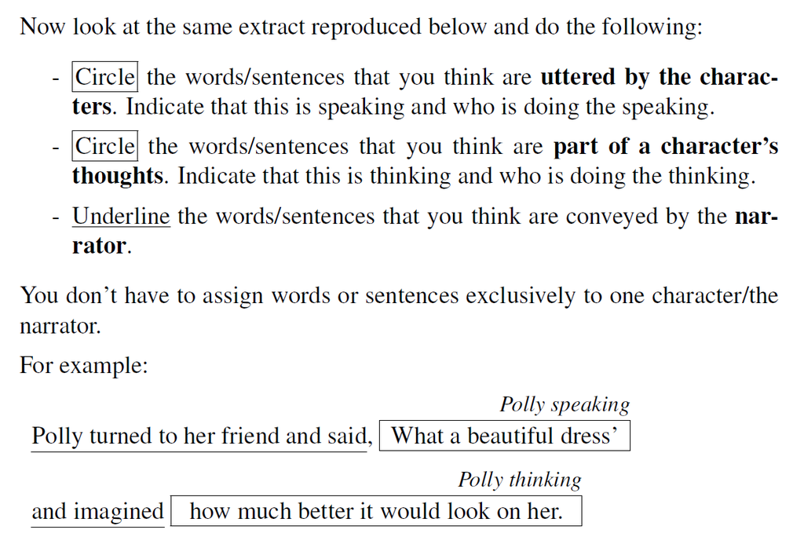

Participants were not told anything about where to place boundaries in the text when making their attributions (e.g. sentence boundaries). They were free to provide attributions for single words, longer sequences of words, clauses, single sentences and multiple sentences. This allowed for complete freedom to attribute perspectives and voices without being directed.

Presentation of the two versions of each passage (modified/unmodified) was counterbalanced, such that individual participants saw only one version of a passage. If readers only completed part of the questionnaire, the completed sections were included in the analysis. This resulted in an unequal number of participants who saw the modified and unmodified versions of the same passage. Because the passages appeared out of context, a brief contextual summary of a sentence or two appeared before each. This was the same for both the modified and unmodified versions. As in the following example, the summaries introduced the main characters and set the scene, and were intended to ensure that participants had enough information to understand the situation depicted in the passage.

*The Ramsays (Mrs. Ramsay, Mr. Ramsay and their daughter Minta), Lily Briscoe, Paul Riley, William Bakes and Charles Tansley are sitting at the table. The dinner has started and the ‘Bœuf en Daube’ is served.*

Participants were given the questionnaire – either a paper copy or an electronic Microsoft Word document. They were asked to go though it page by page, and told not to look back to previous pages when completing a particular page. Participants completed the questionnaire and then they returned it together with a signed consent form.

## Analysis

Processing of the data was done in two stages: first, responses for each passage in each condition (modified/unmodified) were collated. We will consider how this was done with regard to the following sentence, from the passage analysed in the previous section: ‘Oh yes, Sally remembered; she had it still, a ruby ring which Marie Antoinette had given her great-grandfather’ (Woolf, 1996).

Table 3: Example of different attributions by three representative participants (A, B and C)

| Participant A | Sally speaking | Narrator | Sally speaking | Sally speaking | Sally thinking |
| --- | --- | --- | --- | --- | --- |
|  | Oh yes, | Sally remembered | she had it still, a ruby ring which Marie Antoinette had given her great-grandfather. | She never had a penny to her name in those days | and going to Bourton always meant some frightful pinch. |

| Participant B | Sally thinking |  |
| --- | --- | --- |
|  | Oh yes, Sally remembered she had it still, a ruby ring which Marie Antoinette had given her great-grandfather. She never had a penny to her name in those days and going to Bourton always meant some fr… |  |

| Participant C | Sally thinking | Narrator | Sally thinking |
| --- | --- | --- | --- |
|  | Oh yes, Sally remembered | she had it still, a ruby ring which Marie Antoinette had given her great-grandfather. | She never had a penny to her name in those days |

In the second stage of the analysis, we looked at the attributions participants made for the various divisions. As we see in Table 4, because Participant B only made one attribution, the attribution ‘Sally thinking’ is applied across all divisions. For each division, we can then see how many attributions have been made, which is shown at the bottom of Table 4. Crucially, the divisions allowed us to take into account all the possible attributions to the smallest unit of text. Once the maximum number of possible units for a text was established, we applied those same divisions to its other respective original/modified version – depending on which of the two had more divisions – and we looked at the attributions for each unit in both texts. While the number of divisions and how they vary across participants could offer interesting insights into how readers understand the boundaries and shifts between perspectives, they are not the focus of the current investigation and therefore will not be examined further.

Table 4: Example of text subdivision in units basing on the collated attributions for a single sentence by three representative participants (A, B and C)

[output not shown]

# Results

## Difficulty

A paired t-test of the aggregated values per passage was carried out in R (R Development Core Team and Team (2017)) and revealed that the presence of *free indirect style* increased the subjectively experienced difficulty by about 0.63 points on a 3-point-scale, and that this difference is significant (*t*(7) = 5.85, *p* <.001)[^3]. The absence of *free indirect style* decreases subjectively experienced difficulty by about 0.65 points on a 3-point-scale (*t*(143.47) = -6.70, *p* < .001); the degrees of freedom are estimates based on the Satterthwaite method. Cohen’s effect size value (*d* = .82) suggests a high significance.

# Discussion

Some issues with the present study also need to be kept in mind: we tried to select passages that would make sense by themselves, and that did not contain particularly difficult vocabulary; however, because we took extracts from novels, it is possible that the lack of context increased the difficulty for readers. Nonetheless, this should not influence the overall pattern of results, as it is true for both original and modified passages. Finally, despite our effort to minimize changes as much as possible, any modification inevitably changed the original texts, slightly altering their syntax and therefore potentially their reception. To limit the impact of this phenomenon, every word or sentence that was added to the modified versions to make the identification of perspectives easier – for example the conjunction that or the inquit he/she said – was excluded from the analysis.

The significant difference in responses to original extracts from Virginia Woolf’s *To the Lighthouse* and *Mrs Dalloway*, which featured *free indirect style* and/or interior monologue, and modified versions of the same extracts where this technique were simplified by removing as much as possible potential ambiguities, confirms that *free indirect style* is indeed at the root of difficulty that readers experience when confronted with Woolf’s texts. The difficulty associated with its interpretation appears to derive from the lack of explicit boundaries between the different modes of speech/thought presentation and the lack of demarcation of voices and perspectives in the texts.

# References

50 Incredibly Tough Books for Extreme Readers (2013). Available at: http://flavorwire.com/423424/50-incredibly-tough-books-for-extreme-readers/19 (accessed 17 February 2017).

Adamson S (1994) Subjectivity in narration: empathy and echo. *Subjecthood and subjectivity: The status of the subject in linguistic theory*. Institut Français du Royaume-Uni Ophrys: 193–208.

Adamson S (1998) The code as context: language-change and (mis) interpretation. *Context in Language Learning and Language Understanding*. Cambridge University Press: 137–168.

Banfield A (1982) Unspeakable sentences. *Narration and Representation in the*.

Biber D and Finegan E (1989) Styles of stance in English: Lexical and grammatical marking of evidentiality and affect. *Text-interdisciplinary journal for the study of discourse* 9(1). Walter de Gruyter, Berlin/New York: 93–124.

Book #13: Mrs. Dalloway | 101 Books (2011). Available at: https://101books.net/2011/03/21/book-13-mrs-dalloway/ (accessed 17 February 2017).

Bosseaux C (2007) *How Does it Feel?: Point of View in Translation : the Case of Virginia Woolf Into French*. Rodopi.

Bray J (2007a) The ‘dual voice’of free indirect discourse: a reading experiment. *Language and Literature* 16(1): 37–52. DOI: 10.1177/0963947007072844.

Bray J (2007b) The effects of free indirect discourse: Empathy revisited. *Contemporary Stylistics*. Continuum London: 56–67.

Brinton L (1980) ‘Represented perception’: A study in narrative style. *Poetics* 9(4): 363–381.

Brooke J, Hammond A and Hirst G (2016) Using Models of Lexical Style to Quantify Free Indirect Discourse in Modernist Fiction. *Digital Scholarship in the Humanities*. DOI: 10.1093/llc/fqv072.

Castiglione D (2019) *Difficulty in Poetry: A Stylistic Model*. Springer Nature Customer Service Center Gmbh. Available at: https://books.google.co.uk/books?id=WQVEwAEACAAJ.

Cohn D (1978) *Transparent minds: Narrative modes for presenting consciousness in fiction*. Princeton University Press.

Cui Y (2017) Reader responses to shifts in point of view: An empirical study. *Language and Literature* 26(2). SAGE Publications Ltd: 122–136. DOI: 10.1177/0963947017704727.

Diepeveen L (2003) *The Difficulties of Modernism*. Taylor & Francis.

Flood A (2012) The world’s most difficult books: how many have you read?

Fludernik M (1996) *Towards a ’Natural’ Narratology*. Routledge.

Galbraith M (2012) Deictic shift theory and the poetics of involvement in narrative. In: *Deixis in narrative: A cognitive science perspective*. Psychology Press, pp. 19–59.

Goldman J (2006) *The Cambridge Introduction to Virginia Woolf*. Cambridge University Press.

Leaska MA (1970) *Virginia Woolf’s Lighthouse: a study in critical method*. Chatto & Windus.

Leech G and Short M (2007) *Style in Fiction*. 2nd ed. Pearson Education Limited.

Levenson MH (2013) Why We’re Still Struggling to Make Sense of Modernism. *The Atlantic*. Available at: https://www.theatlantic.com/magazine/archive/2013/10/the-shock-of-the-new/309451/.

Mahaffey V (2008) *Modernist Literature: Challenging Fictions?* John Wiley & Sons.

Matz J (2008) *The modern novel: A short introduction*. John Wiley & Sons.

Miall D (1989) Beyond the schema given: Affective comprehension of literary narratives. *Cognition and Emotion* 3(1). Routledge: 55–78. DOI: 10.1080/02699938908415236.

Most Difficult Novels (399 books) (2017). Available at: [https://www.goodreads.com/list/show/827.Most{\_}Difficult{\_}Novels](https://www.goodreads.com/list/show/827.Most%7B\_%7DDifficult%7B\_%7DNovels) (accessed 17 February 2017).

Palmer A (2004) *Fictional Minds*. University of Nebraska Press.

Pascal R (1977) *The Dual Voice: Free Indirect Speech and Its Functioning in the Nineteenth-century European Novel*. Manchester University Press.

Quigley M (2015) *Modernist Fiction and Vagueness*. Cambridge University Press.

R Development Core Team and Team RC (2017) R: A language and environment for statistical computing. Vienna, Austria: Vienna, Austria.

Rundquist E (2014) How is Mrs Ramsay thinking? The semantic effects of consciousness presentation categories within free indirect style. *Language and Literature, 23(2)*: 159–174.

Rundquist E (2015) Consciousness. In: Sotirova V (ed.) *The bloomsbury companion to stylistics*. Bloomsbury Academic, pp. 380–399.

Semino E, Short M and Culpeper J (1997) Using a corpus to test a model of speech and thought presentation. *Poetics* 25(1): 17–43. DOI: 10.1016/S0304-422X(97)00007-7.

Sotirova V (2006) Reader responses to narrative point of view. *Poetics 34(2)*: 108–133.

Sotirova V (2007) Woolf’s Experiments with Consciousness in Fiction. In: Lambrou M and Stockwell P (eds) *Contemporary stylistics*. Continuum New York, pp. 7–18.

Sotirova V (2011) *D. H. Lawrence and Narrative Viewpoint*. Continuum International Publishing Group.

Sotirova V (2013) *Consciousness in Modernist Fiction: A Stylistic Study*. Palgrave Macmillan.

Sotirova V (2016) Empirical stylistics as a learning and research tool in the study of narrative viewpoint. Burke M, Fialho O, and Zyngier S (eds) *Scientific Approaches to Literature in Learning Environments*: 227–252. DOI: 10.1075/lal.24.12sot.

Top 100 Most Difficult Novels (2017). Available at: http://www.listchallenges.com/goodreads-top-100-most-difficult-novels (accessed 17 February 2017).

Van Peer W (2007) Introduction to foregrounding: A state of the art. *Language and Literature* 16(2). Sage Publications Sage UK: London, England: 99–104.

Van Peer W, Hakemulder F and Zyngier S (2007) Lines on feeling: foregrounding, aesthetics and meaning. *Language and Literature* 16(2). SAGE Publications Ltd: 197–213. DOI: 10.1177/0963947007075985.

Wilkinson EC and Hallberg GR (2012) The Top 10 Most Difficult Books. Available at: https://www.publishersweekly.com/pw/by-topic/industry-news/tip-sheet/article/53409-the-top-10-most-difficult-books.html (accessed 17 February 2017).

Wilson JJ (1981) Why is Orlando difficult? In: *New feminist essays on virginia woolf*. Springer, pp. 170–184.

Woolf V (1994) *To the Lighthouse*. Wordsworth Classics.

Woolf V (1996) *Mrs Dalloway*. Wordsworth Classics.

Zunshine L, Spolsky E, Richardson A, et al. (2003) Theory of mind and experimental representations of fictional consciousness. *Narrative* 11(3). The Ohio State University Press: 270–291. DOI: 10.1353/nar.2003.0018.

Zyngier S, Van Peer W and Hakemulder F (2007) Complexity and Foregrounding: In the Eye of the Beholder? *Poetics Today* 28(4): 653–682. DOI: 10.1215/03335372-2007-011.

[^1]: Based on actual readers’ ratings, various online magazines propose a ranking of the ‘most difficult novels of all times’. Woolf’s To the Lighthouse and Mrs Dalloway feature in most surveys among the first twenty positions - see for example Flood (2012); Wilkinson and Hallberg (2012); (Most Difficult Novels (399 books), 2017); (Top 100 Most Difficult Novels, 2017); (50 Incredibly Tough Books for Extreme Readers, 2013); (Book #13: Mrs. Dalloway | 101 Books, 2011).
[^2]: Readers were asked to read the passage once, and then were guided to read the same passage again to answer the question ‘whose point(s) of view is the passage narrated from?’. Because they could not interact with the text, nor take notes, it seems plausible that readers would not necessarily be able to recall and report all the possible viewpoints conveyed, especially if no guidelines were given in terms of which viewpoints should be taken into account (the characters’ only, the narrator, multiple perspectives).
[^3]: The *t*-value measures the size of the difference relative to the variation in a sample.